# Testing for the number of interesting components in ICA

Klaus Nordhausen, Hannu Oja, David E. Tyler, Joni Virta

2026-11-16

## Fourth order blind identification

In independent component analysis (ICA) it is usually assumed that the observable $p$-vector $x$ is a linear mixture of $p$ mutually independent components, where the vector of independent components is $s$. Hence the model can be written as
$$x = As + \mu,$$
where the full rank $A$ represents the linear mixing and $\mu$ the location. It is then usually assumed that $E(s)=0$ and $Cov(s)=I_p$. The goal is then to find an unmixing matrix $W$ such that $Wx$ has independent components.

In ICA gaussian components are considered the uninteresting ones whereas the non-gaussian ones are considered interesting. Actually, if there is more than one gaussian component only the non-gaussian components can be recovered but not the gaussian ones.

Therefore it is naturally of interest to test how many interesting components there are. This is done by testing if a subvector of $Wx$ is gaussian.

FOBI is one of the first ICA methods - it jointly diagonalizes the regular covariance matrix $Cov$ and the so-called matrix of fourth moments
$$Cov_4(x) = E(r^2(x-\mu)(x-\mu)^T),$$
where $\mu = E(x)$ and $r^2=(x-\mu)^T Cov(x)^{-1} (x-\mu)$.

Note that under this definition $Cov_4$ is not consistent under the normal model and the scale of a normal component would be $\sqrt{p+2}$. (Therefore for example the function `cov4` from the `ICS` package divides $Cov_4$ by $p+2$.)

Hence FOBI is the solution to the generalized eigenvector-eigenvalue problem which solves
$$W Cov(x) W^T = I_p \ and \ W Cov_4(x) W^T = D,$$
where D is a diagonal matrix.

For the context under consideration it is natural to order the general eigenvectors in $W$ such that the eigenvalues, which are the diagonal elements of $D$, $d_1,...,d_p$, fulfill
$$(d_1 - (p+2))^2 \geq ... \geq (d_p - (p+2))^2,$$
which means gaussian components would be put at the end of $s$ and values of $d_i$’s which correspond to a gaussian component should be $p+2$.

Hence, assuming that there are $k$ interesting components the hypothesis is that
$$H_0: d_{k+1} = ... = d_p = p+2.$$
The package `ICtest` provides different asymptotic and bootstrapping based tests to test this hypothesis

### Asymptotic tests for a specific value of $k$

The function for the asymptotic test is `FOBIasymp` and it provides three different tests, denoted by `S1`, `S2` and `S3`, and specified using the `type` argument:

1. `type="S1"`: The test statistic $T$ is the variance of the last $p-k$ eigenvalues around p+2:
   $$T = n \sum_{i=k+1}^p (d_i-(p+2))^2$$

the limiting distribution of $T$ under the null is the sum of two weighted chisquare distributions with weights $w_1 = 2 \sigma_1 / (p-k)$ and $w_2 = 2 \sigma_1 / (p-k) + \sigma_2$ and degrees of freedom $df_1 = (p-k-1)(p-k+2)/2$ and $df_2 = 1$.

2. `type="S2"`: Another possible version for the test statistic is a scaled sum of the variance of the eigenvalues around the mean plus the variance around the expected value under normality ($p+2$). Denote $VAR_{dpk}$ as the variance of the last $p-k$ eigenvalues and $VAR2_{dpk}$ as the variance of these eigenvalues around $p+2$.

Then the test statistic is:
$$T = (n (p-k) VAR_{dpk}) / (2 \sigma_1) + (n VAR2_{dpk}) / (2 \sigma_1 /
(p-k) + \sigma_2)$$
This test statistic has a limiting chisquare distribution with $(p-k-1)(p-q+2)/2 + 1$ degrees of freedom.

3. `type="S3"`: The third possible test statistic just checks the equality of the last $p-k$ eigenvalues using only the first part of the test statistic of `type="S2"`.

The test statistic is then:
$$T = (n (p-k) VAR_{dpk}) / (2 \sigma_1)$$
and has a limiting chisquare distribution with $(p-k-1)(p-q+2)/2$ degrees of freedom.

The constants $\sigma_1$ and $\sigma_2$ depend on the kurtosis values of the independent components and on the dimension $p$ and are estimated from the data.

To demonstrate the function `FOBIasymp` consider the following artificial data

```r
library(ICtest)
set.seed(1)
n <- 1500
S <- cbind(runif(n), rchisq(n, 2), rexp(n), rnorm(n), rnorm(n), rnorm(n))
A <- matrix(rnorm(36), ncol = 6)
X <- S  %*% t(A)
```

Therefore there are three interesting components and three noise components.

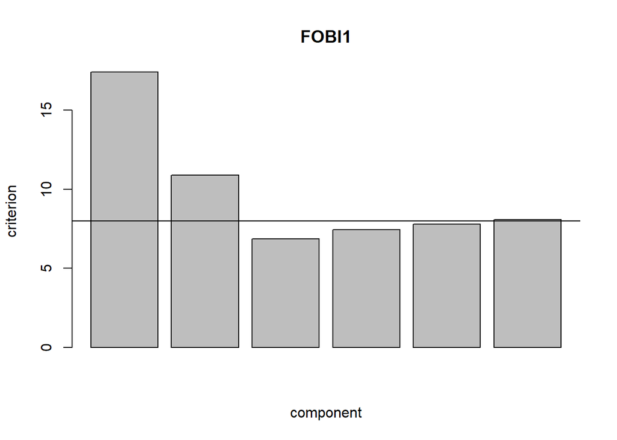

```r
FOBI1 <- FOBIasymp(X, k = 3, model="ICA")
screeplot(FOBI1)
abline(h = 8) # p=6, i.e. p + 2 = 8
```

The screeplot shows that the components are in the right order and 3 components have an eigenvalue close to the value of interest.

The test decision is

```r
FOBI1
```

```
##
##  FOBI subgaussianity test using a chisquare test (Variant II)
##  in an ICA model
##
## data:  X
## T = 4.5359, df = 5, p-value = 0.4751
## alternative hypothesis: there are fewer than 3 gaussian components
```

Which we can compare to the other test version:

```r
FOBIasymp(X, k = 3, type = "S1", model = "ICA")
```

```
##
##  FOBI subgaussianity test using a weighted sum of chisquare test
##  in an ICA model
##
## data:  X
## T = 175.81, w1 = 21.324, df1 = 5.000, w2 = 25.324, df2 = 1.000, p-value
## = 0.2387
## alternative hypothesis: there are fewer than 3 gaussian components
```

```r
FOBIasymp(X, k = 3, type = "S2", model = "ICA")
```

```
##
##  FOBI subgaussianity test using a chisquare test (Variant I)
##  in an ICA model
##
## data:  X
## T = 7.6589, df = 6, p-value = 0.2642
## alternative hypothesis: there are fewer than 3 gaussian components
```

which means all three tests do not reject that the last three components are gaussian. Using the default, `model = "NGCA"` should be also consistent but does not explicitely assume an ICA model but the more general non-gaussian component analysis (NGCA) model with possible dependent interesting signals.

To see if there are 4 gaussian components using the default `model` argument one could use for example:

```r
FOBIasymp(X, k = 2)
```

```
##
##  FOBI subgaussianity test using a chisquare test (Variant II)
##  in an NGCA model
##
## data:  X
## T = 20.455, df = 9, p-value = 0.01531
## alternative hypothesis: there are fewer than 4 gaussian components
```

which would be rejected at the $0.05$ level.

### Bootstrapping tests for a specific value of $k$

The test statistic used here is again the variance of the last $p-k$ components around the value of interest $p+2$:
$$T = n \sum_{i=k+1}^p (d_i-(p+2))^2$$
Two possible bootstrap testing strategies, denoted `B1` and `B2`, are provided for testing the null hypothesis of interest.

Let $X$ be the centered data matrix of the $n$ $p$-variate observations and $S$ the corresponding estimated independent components which can be decomposed into $S_1$, the non-gaussian components and $S_2$ the gaussian components. Let $W$ be the estimated unmixing matrix.

1. `s.boot="B1"`: The first strategy has the following steps:
1. Take a bootstrap sample $S_1^*$ of size $n$ from $S_1$.
2. Take a bootstrap sample $S_2^*$ consisting of a matrix of standard normally distributed elements.
3. Combine $S^*=(S_1^*, S_2^*)$ and create $X^*= S^* W^{-1}$.
4. Compute the test statistic $T^*$ based on $X^*$.
5. Repeat the previous steps `n.boot` times to get the test statistics $T^*_1,..., T^*_{n.boot}$.

Note that in this bootstrapping test the assumption of ‘’independent components’’ is not used, it is only used that the last $p-k$ components are gaussian and independent from the first $k$ components. Therefore this strategy can be applied in an independent component analysis (ICA) framework and in a non-gaussian components analysis (NGCA) framework.

2. `s.boot="B2"`: The second strategy has the following steps:
1. Take a bootstrap sample $S_1^*$ of size $n$ from $S_1$ where the subsampling is done separately for each independent component.
2. Take a bootstrap sample $S_2^*$ consisting of a matrix of standard normally distributed elements.
3. Combine $S^*=(S_1^*, S_2^*)$ and create $X^*= S^* W^{-1}$.
4. Compute the test statistic $T^*$ based on $X^*$.
5. Repeat the previous steps `n.boot` times to get the test statistics $T^*_1,..., T^*_{n.boot}$.

The p-value is then in both cases
$$\frac{\#(T_i^* \geq T)+1}{n.boot+1}.$$

This bootstrapping strategy assumes a full ICA model and cannot be used in an NGCA framework.

To test for the previous data whether there are three gaussian components, the bootstrap `FOBIboot` can be used as follows:

```r
FOBIboot(X, k = 3, s.boot = "B1")
```

```
##
##  ICA subgaussianity bootstrapping test using FOBI and strategy B1
##
## data:  X
## T = 527.43, replications = 200, p-value = 0.194
## alternative hypothesis: the last 3 components are not gaussian
```

```r
FOBIboot(X, k = 3, s.boot = "B2")
```

```
##
##  ICA subgaussianity bootstrapping test using FOBI and strategy B2
##
## data:  X
## T = 527.43, replications = 200, p-value = 0.1493
## alternative hypothesis: the last 3 components are not gaussian
```

## Non-Gaussian projection pursuit

Non-Gaussian projection pursuit (NGPP) assumes that the observed multivariate data is generated by a linear mixture of $k$ signals and $p - k$ channels of Gaussian noise. The package provides both methods for estimating the signals when $k$ is known *a priori* and a technique for testing and estimating the value of $k$ itself. The estimation is based on the maximization of convex combinations of squared objective functions, of which four popular ones are included in the package:

- Third cumulant, `skew`
- Fourth cumulant, `pow3`
- Logarithmic hyperbolic cosine, `tanh`
- Gaussian function, `gauss`

The names (`skew` etc.) of the functions in the package are based on the corresponding derivatives, or *non-linearities*.

### Estimating the signal components

The simplest way to use NGPP is to just call the function using default settings and indicating the number of signal components `k` you want to extract. The default objective function is a certain linear combination of squared third and fourth cumulants, the *Jarque-Bera* test statistic for normality. To use some other objective function you can specify a vector of objective function names in `nl` and the corresponding weights in `alpha`.

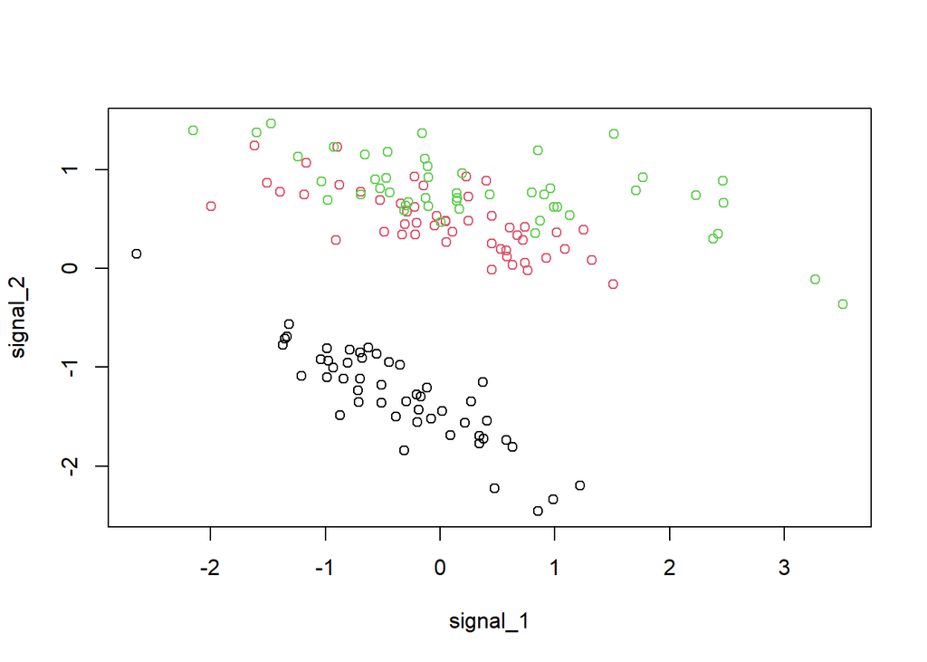

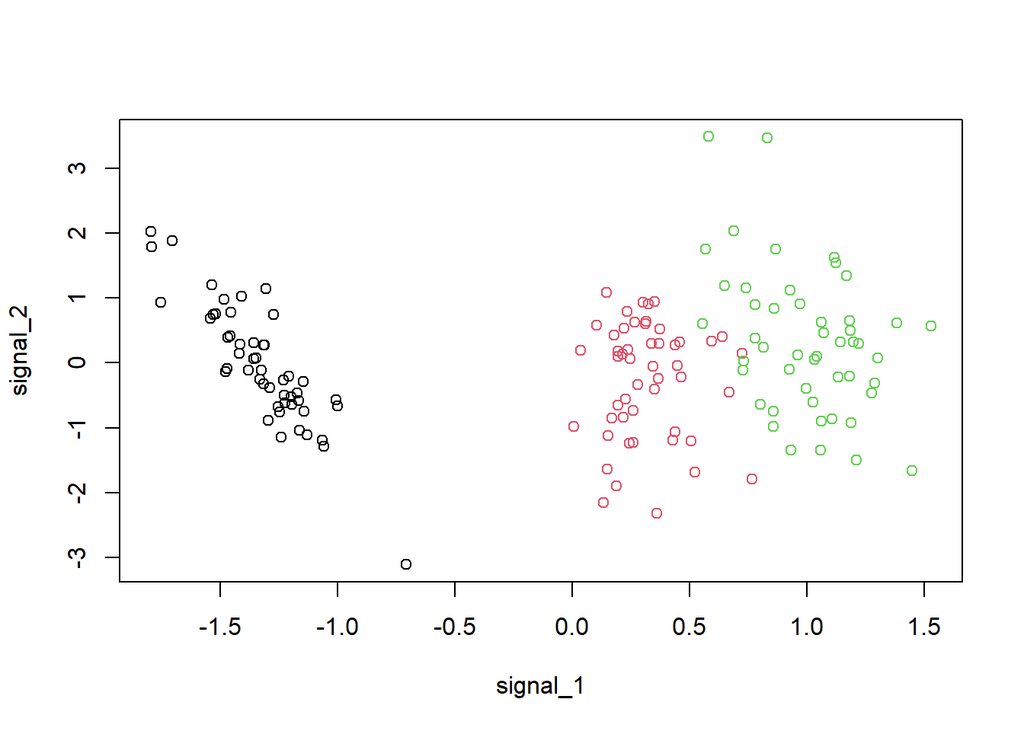

```r
library(ICtest)
X <- as.matrix(iris[, 1:4])

res1 <- NGPP(X, k = 2)
plot(res1$S, col = as.factor(iris[, 5]), xlab = "signal_1", ylab = "signal_2")

res2 <- NGPP(X, k = 2, nl=c("tanh", "pow3"), alpha = c(0.5, 0.5))
plot(res2$S, col = as.factor(iris[, 5]), xlab = "signal_1", ylab = "signal_2")
```

### Testing for a specific value of $k$

The above example used the default `method="symm"` to specify that all `k` signals should be estimated simultaneously and the alternative `method="defl"` could have been used to estimate the signals one-by-one, leading into different solutions. But perhaps more interestingly, the one-by-one estimation can also be used to test the null hypothesis $H_0: true\_k \leq k$ with the function `NGPPsim`. Let’s create next some mixed toy data and try to infer its true signal dimension.

```r
set.seed(2016)
S <- cbind(rexp(100), rnorm(100), rnorm(100))
A <- matrix(rnorm(9), 3, 3)
X <- S%*%A
res0 <- NGPPsim(X, k = 0, N = 200)
res0$p.value
```

```
## [1] 0.004975124
```

```r
res1 <- NGPPsim(X, k = 1, N = 200)
res1$p.value
```

```
## [1] 0.9353234
```

The obtained $p$-values provide sufficient evidence to conclude that $k\_true > 0$ and $k\_true \leq 1$, correctly implying that the signal dimension is equal to one. The parameter `N` controls the number of repetitions used to simulate the distribution of the test statistic under the null hypothesis and increasing it gives more accurate results but increases the computation time.

### Estimation of the true dimension

In the above example we had to separately call `NGPPsim` for each value of `k`. This process is automated by the function `NGPPest` which performs the hypothesis test for all $k = 0, \ldots , p-1$. Let’s create another toy data and try to estimate its dimension, using this time only the non-linearity `pow3`.

```r
set.seed(2016)
S <- cbind(rexp(100), runif(100), rnorm(100))
A <- matrix(rnorm(9), 3, 3)
X <- S%*%A
res <- NGPPest(X, nl = "pow3", N = 200)
res$p.value
```

```
## [1] 0.004975124 0.084577114 0.855721393
```